# Praktikum 7 (Trasnformasi Box-Cox)

Nabil Bintang Prayoga

2025-03-10

Asumsi sisaan yang harus dipenuhi dari model regresi linear adalah sebagai berikut:  
1. Nilai harapan galat sama dengan nol $(E[\varepsilon_i]=0)$  
2. Homoskedastisitas atau ragam galat homogen $(Var[\varepsilon]=\sigma^2I)$  
3. Autokorelasi atau galat saling bebas $(E[\varepsilon_i,\varepsilon_j]=0)$  
4. Galat menyebar Normal $(\varepsilon-N(0,\sigma^2I))$  
5. Tidak ada multikolinearitas antarpeubah bebas $(cov(x_i,x_j)=0,∀i≠j)$  
Jika terdapat asumsi sisaan yang dilanggar pada model, maka diperlukan penanganan kondisi tak standar

# Library

```r
library(dplyr) #untuk manipulasi data
library(GGally) #visualisasi hubungan peubah
library(psych) #analisis data/korelasi
library(car) #untuk multikolinearitas dan uji durbin
library(lmtest) #untuk uji breusch pagan
```

```r
library(corrplot) #visualisasi korelasi
library(nortest) #untuk uji lilliofers
library(MASS) #Box-Cox
```

# Data

```r
data <- as.data.frame(state.x77) # data bawaan software
data <- data %>% dplyr::select(Income, everything())
data <- data[,-7]
data
```

```
##                Income Population Illiteracy Life Exp Murder HS Grad   Area
## Alabama          3624       3615        2.1    69.05   15.1    41.3  50708
## Alaska           6315        365        1.5    69.31   11.3    66.7 566432
## Arizona          4530       2212        1.8    70.55    7.8    58.1 113417
## Arkansas         3378       2110        1.9    70.66   10.1    39.9  51945
## California       5114      21198        1.1    71.71   10.3    62.6 156361
## Colorado         4884       2541        0.7    72.06    6.8    63.9 103766
## Connecticut      5348       3100        1.1    72.48    3.1    56.0   4862
## Delaware         4809        579        0.9    70.06    6.2    54.6   1982
## Florida          4815       8277        1.3    70.66   10.7    52.6  54090
## Georgia          4091       4931        2.0    68.54   13.9    40.6  58073
## Hawaii           4963        868        1.9    73.60    6.2    61.9   6425
## Idaho            4119        813        0.6    71.87    5.3    59.5  82677
## Illinois         5107      11197        0.9    70.14   10.3    52.6  55748
## Indiana          4458       5313        0.7    70.88    7.1    52.9  36097
## Iowa             4628       2861        0.5    72.56    2.3    59.0  55941
## Kansas           4669       2280        0.6    72.58    4.5    59.9  81787
## Kentucky         3712       3387        1.6    70.10   10.6    38.5  39650
## Louisiana        3545       3806        2.8    68.76   13.2    42.2  44930
## Maine            3694       1058        0.7    70.39    2.7    54.7  30920
## Maryland         5299       4122        0.9    70.22    8.5    52.3   9891
## Massachusetts    4755       5814        1.1    71.83    3.3    58.5   7826
## Michigan         4751       9111        0.9    70.63   11.1    52.8  56817
## Minnesota        4675       3921        0.6    72.96    2.3    57.6  79289
## Mississippi      3098       2341        2.4    68.09   12.5    41.0  47296
## Missouri         4254       4767        0.8    70.69    9.3    48.8  68995
## Montana          4347        746        0.6    70.56    5.0    59.2 145587
## Nebraska         4508       1544        0.6    72.60    2.9    59.3  76483
## Nevada           5149        590        0.5    69.03   11.5    65.2 109889
## New Hampshire    4281        812        0.7    71.23    3.3    57.6   9027
## New Jersey       5237       7333        1.1    70.93    5.2    52.5   7521
## New Mexico       3601       1144        2.2    70.32    9.7    55.2 121412
## New York         4903      18076        1.4    70.55   10.9    52.7  47831
## North Carolina   3875       5441        1.8    69.21   11.1    38.5  48798
## North Dakota     5087        637        0.8    72.78    1.4    50.3  69273
## Ohio             4561      10735        0.8    70.82    7.4    53.2  40975
## Oklahoma         3983       2715        1.1    71.42    6.4    51.6  68782
## Oregon           4660       2284        0.6    72.13    4.2    60.0  96184
## Pennsylvania     4449      11860        1.0    70.43    6.1    50.2  44966
## Rhode Island     4558        931        1.3    71.90    2.4    46.4   1049
## South Carolina   3635       2816        2.3    67.96   11.6    37.8  30225
## South Dakota     4167        681        0.5    72.08    1.7    53.3  75955
## Tennessee        3821       4173        1.7    70.11   11.0    41.8  41328
## Texas            4188      12237        2.2    70.90   12.2    47.4 262134
## Utah             4022       1203        0.6    72.90    4.5    67.3  82096
## Vermont          3907        472        0.6    71.64    5.5    57.1   9267
## Virginia         4701       4981        1.4    70.08    9.5    47.8  39780
## Washington       4864       3559        0.6    71.72    4.3    63.5  66570
## West Virginia    3617       1799        1.4    69.48    6.7    41.6  24070
## Wisconsin        4468       4589        0.7    72.48    3.0    54.5  54464
## Wyoming          4566        376        0.6    70.29    6.9    62.9  97203
```

# Pemodelan Regresi Linear

## Eksplorasi Data

Sebagai langkah awal analisis, dirasa perlu melakukan eksplorasi terhadap seluruh peubah yang digunakan. Eksplorasi paling dasar dalam proses analisis regresi adalah pengecekan sebaran tiap peubah dan deteksi potensi amatan anomali (pencilan maupun leverage). Tiap peubah tentunya diharapkan menyebar (atau menyerupai sebaran) Normal dan bebas dari amatan anomali.

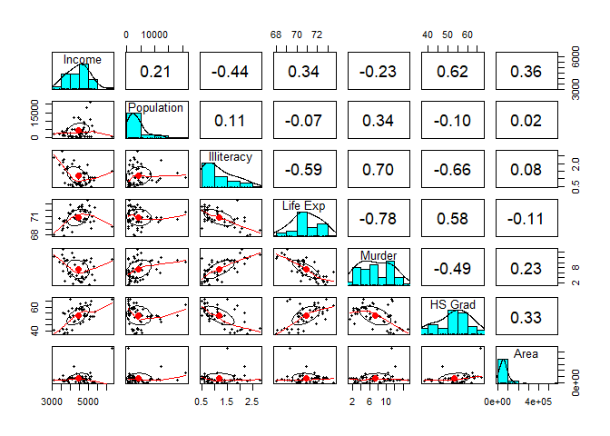

```r
pairs.panels(data)
```

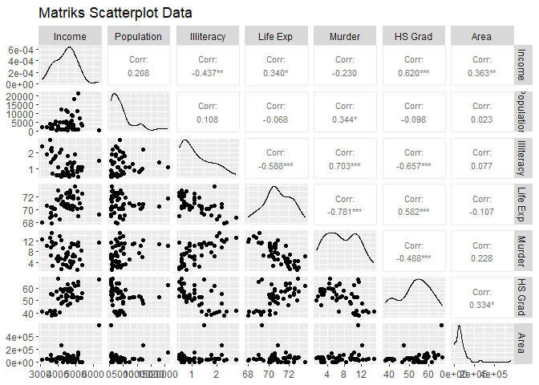

```r
ggpairs(data,
        upper = list(continuous = wrap('cor', size = 3)),
        title = "Matriks Scatterplot Data")
```

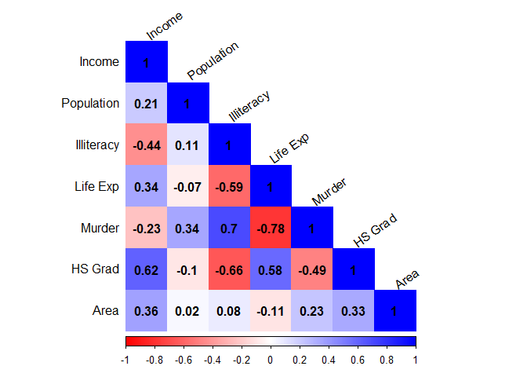

```r
cor_matrix <- cor(data, use = "complete.obs")

corrplot(cor_matrix, method = "color", type = "lower",
         col = colorRampPalette(c("red", "white", "blue"))(200),
         addCoef.col = "black", tl.col = "black", tl.srt = 35)
```

Hasil eksplorasi terhadap hubungan setiap peubah X dengan Y menyatakan bahwa peubah Income memiliki hubungan yang positif terhadap Population, Lixe Expectation, HS Grad, dan Area serta hubungan yang negatif terhadap Illiteracy dan Murder.

## Pemodelan

```r
model <- lm(Income~., data = data)
(vif_model <- vif(model))
```

```
## Population Illiteracy `Life Exp`     Murder  `HS Grad`       Area
##   1.368406   2.974850   3.510591   4.852331   2.955145   1.539652
```

Setelah dilakukan pengujian, diketahui bahwa tidak terdapat multikolinearitas antarpeubah penjelas. Hal ini diindikasikan oleh nilai VIF < 10 pada seluruh peubah penjelas yang digunakan.

```r
summary(model)
```

```
##
## Call:
## lm(formula = Income ~ ., data = data)
##
## Residuals:
##     Min      1Q  Median      3Q     Max
## -896.22 -229.39  -51.62  233.70  963.04
##
## Coefficients:
##               Estimate Std. Error t value Pr(>|t|)
## (Intercept)  3.411e+03  6.457e+03   0.528   0.6000
## Population   3.960e-02  1.739e-02   2.277   0.0278 *
## Illiteracy  -1.557e+02  1.878e+02  -0.829   0.4116
## `Life Exp`  -1.114e+01  9.265e+01  -0.120   0.9048
## Murder      -1.255e+01  3.961e+01  -0.317   0.7529
## `HS Grad`    3.392e+01  1.413e+01   2.401   0.0208 *
## Area         1.690e-03  9.653e-04   1.751   0.0872 .
## ---
## Signif. codes:  0 '***' 0.001 '**' 0.01 '*' 0.05 '.' 0.1 ' ' 1
##
## Residual standard error: 464.7 on 43 degrees of freedom
## Multiple R-squared:  0.4982, Adjusted R-squared:  0.4281
## F-statistic: 7.114 on 6 and 43 DF,  p-value: 2.618e-05
```

Pemodelan menggunakan seluruh peubah menyiratkan bahwa hanya peubah penjelas Population dan HS Grad yang berpengaruh signifikan dalam taraf nyata 5% terhadap peubah respon Income. Penyeleksian peubah dapat dilakukan agar model yang dihasilkan terbaik dalam hal signifikansi peubah.

# Seleksi Peubah

## Metode Backward

```r
step(lm(Income~.,data=data),direction="backward")
```

```
## Start:  AIC=620.59
## Income ~ Population + Illiteracy + `Life Exp` + Murder + `HS Grad` +
##     Area
##
##              Df Sum of Sq      RSS    AIC
## - `Life Exp`  1      3123  9287803 618.61
## - Murder      1     21669  9306348 618.71
## - Illiteracy  1    148423  9433102 619.39
## <none>                     9284679 620.59
## - Area        1    661657  9946336 622.03
## - Population  1   1119285 10403965 624.28
## - `HS Grad`   1   1244587 10529267 624.88
##
## Step:  AIC=618.61
## Income ~ Population + Illiteracy + Murder + `HS Grad` + Area
##
##              Df Sum of Sq      RSS    AIC
## - Murder      1     22308  9310111 616.73
## - Illiteracy  1    165140  9452943 617.49
## <none>                     9287803 618.61
## - Area        1    677009  9964812 620.13
## - Population  1   1236798 10524600 622.86
## - `HS Grad`   1   1416372 10704174 623.71
##
## Step:  AIC=616.73
## Income ~ Population + Illiteracy + `HS Grad` + Area
##
##              Df Sum of Sq      RSS    AIC
## - Illiteracy  1    307844  9617955 616.36
## <none>                     9310111 616.73
## - Area        1    670178  9980289 618.20
## - Population  1   1306229 10616339 621.29
## - `HS Grad`   1   1555728 10865839 622.46
##
## Step:  AIC=616.36
## Income ~ Population + `HS Grad` + Area
##
##              Df Sum of Sq      RSS    AIC
## <none>                     9617955 616.36
## - Area        1    418138 10036092 616.48
## - Population  1   1262741 10880696 620.52
## - `HS Grad`   1   5700334 15318289 637.63
```

```
##
## Call:
## lm(formula = Income ~ Population + `HS Grad` + Area, data = data)
##
## Coefficients:
## (Intercept)   Population    `HS Grad`         Area
##   1.807e+03    3.620e-02    4.508e+01    1.150e-03
```

## Metode Forward

Prosedur seleksi peubah dengan metode forward berjalan sebagai berikut  
1. Langkah dimulai dengan melakukan pemodelan hanya terhadap intersep  
2. Selanjutnya, satu per satu peubah penjelas akan dimasukkan ke model berdasarkan nilai koefisien korelasi yang paling besar terhadap peubah respons  
4. Peubah penjelas yang telah dimasukkan tidak akan dieliminasi dari model  
5. Imputasi peubah penjelas terus dilakukan hingga diperoleh model terbaik berdasarkan metrik yang diacu (biasanya AIC)

```r
step(lm(Income~1,data=data),direction="forward",
     scope=~Population + Illiteracy + `Life Exp` + Murder + `HS Grad` + Area)
```

```
## Start:  AIC=643.07
## Income ~ 1
##
##              Df Sum of Sq      RSS    AIC
## + `HS Grad`   1   7110267 11390825 620.81
## + Illiteracy  1   3534351 14966741 634.47
## + Area        1   2442109 16058983 637.99
## + `Life Exp`  1   2141940 16359152 638.91
## + Murder      1    979368 17521724 642.35
## + Population  1    802184 17698908 642.85
## <none>                    18501092 643.07
##
## Step:  AIC=620.81
## Income ~ `HS Grad`
##
##              Df Sum of Sq      RSS    AIC
## + Population  1   1354732 10036092 616.48
## + Area        1    510129 10880696 620.52
## <none>                    11390825 620.81
## + Murder      1    127398 11263427 622.25
## + Illiteracy  1     28654 11362170 622.69
## + `Life Exp`  1     11969 11378856 622.76
##
## Step:  AIC=616.48
## Income ~ `HS Grad` + Population
##
##              Df Sum of Sq      RSS    AIC
## + Area        1    418138  9617955 616.36
## <none>                    10036092 616.48
## + Illiteracy  1     55804  9980289 618.20
## + `Life Exp`  1      8837 10027256 618.44
## + Murder      1      1733 10034359 618.48
##
## Step:  AIC=616.36
## Income ~ `HS Grad` + Population + Area
##
##              Df Sum of Sq     RSS    AIC
## <none>                    9617955 616.36
## + Illiteracy  1    307844 9310111 616.73
## + Murder      1    165012 9452943 617.49
## + `Life Exp`  1     30414 9587541 618.20
```

```
##
## Call:
## lm(formula = Income ~ `HS Grad` + Population + Area, data = data)
##
## Coefficients:
## (Intercept)    `HS Grad`   Population         Area
##   1.807e+03    4.508e+01    3.620e-02    1.150e-03
```

## Metode Stepwise

Sementara itu, prosedur seleksi peubah stepwise merupakan kombinasi antara metode backward dan forward. Model pertama yang dibentuk adalah model dengan seluruh peubah penjelas yang kemudian akan dieliminasi satu per satu. Meskipun demikian, peubah yang telah dieliminasi masih memiliki kemungkinan untuk diimputasi kembali ke dalam model.

```r
step(lm(Income~.,data=data),direction="both")
```

```
## Start:  AIC=620.59
## Income ~ Population + Illiteracy + `Life Exp` + Murder + `HS Grad` +
##     Area
##
##              Df Sum of Sq      RSS    AIC
## - `Life Exp`  1      3123  9287803 618.61
## - Murder      1     21669  9306348 618.71
## - Illiteracy  1    148423  9433102 619.39
## <none>                     9284679 620.59
## - Area        1    661657  9946336 622.03
## - Population  1   1119285 10403965 624.28
## - `HS Grad`   1   1244587 10529267 624.88
##
## Step:  AIC=618.61
## Income ~ Population + Illiteracy + Murder + `HS Grad` + Area
##
##              Df Sum of Sq      RSS    AIC
## - Murder      1     22308  9310111 616.73
## - Illiteracy  1    165140  9452943 617.49
## <none>                     9287803 618.61
## - Area        1    677009  9964812 620.13
## + `Life Exp`  1      3123  9284679 620.59
## - Population  1   1236798 10524600 622.86
## - `HS Grad`   1   1416372 10704174 623.71
##
## Step:  AIC=616.73
## Income ~ Population + Illiteracy + `HS Grad` + Area
##
##              Df Sum of Sq      RSS    AIC
## - Illiteracy  1    307844  9617955 616.36
## <none>                     9310111 616.73
## - Area        1    670178  9980289 618.20
## + Murder      1     22308  9287803 618.61
## + `Life Exp`  1      3762  9306348 618.71
## - Population  1   1306229 10616339 621.29
## - `HS Grad`   1   1555728 10865839 622.46
##
## Step:  AIC=616.36
## Income ~ Population + `HS Grad` + Area
##
##              Df Sum of Sq      RSS    AIC
## <none>                     9617955 616.36
## - Area        1    418138 10036092 616.48
## + Illiteracy  1    307844  9310111 616.73
## + Murder      1    165012  9452943 617.49
## + `Life Exp`  1     30414  9587541 618.20
## - Population  1   1262741 10880696 620.52
## - `HS Grad`   1   5700334 15318289 637.63
```

```
##
## Call:
## lm(formula = Income ~ Population + `HS Grad` + Area, data = data)
##
## Coefficients:
## (Intercept)   Population    `HS Grad`         Area
##   1.807e+03    3.620e-02    4.508e+01    1.150e-03
```

## Pemodelan Terbaik

```r
model2 <- lm(Income ~ Population + `HS Grad` + Area, data = data)
summary(model2)
```

```
##
## Call:
## lm(formula = Income ~ Population + `HS Grad` + Area, data = data)
##
## Residuals:
##     Min      1Q  Median      3Q     Max
## -956.47 -225.60  -14.54  198.88  974.12
##
## Coefficients:
##              Estimate Std. Error t value Pr(>|t|)
## (Intercept) 1.807e+03  4.581e+02   3.944 0.000272 ***
## Population  3.620e-02  1.473e-02   2.458 0.017820 *
## `HS Grad`   4.508e+01  8.634e+00   5.221 4.17e-06 ***
## Area        1.150e-03  8.135e-04   1.414 0.164049
## ---
## Signif. codes:  0 '***' 0.001 '**' 0.01 '*' 0.05 '.' 0.1 ' ' 1
##
## Residual standard error: 457.3 on 46 degrees of freedom
## Multiple R-squared:  0.4801, Adjusted R-squared:  0.4462
## F-statistic: 14.16 on 3 and 46 DF,  p-value: 1.137e-06
```

Persamaan regresi yang terbentuk dari hasil penyeleksian peubah adalah sebagai berikut

$$\hat{Y}=1807+0.0362X_1+45.08X_2+0.0012X_3$$

Dari ketiga peubah tersebut, hanya Area yang tidak signifikan pada taraf nyata 5%. Hasil adjusted R square sedikit meningkat dari model dengan seluruh peubah, yakni menjadi 0.4462

# Diagnostik Sisaan / Pengujian Asumsi

## Eksplorasi Grafik

### Plot Sisaan vs Yduga

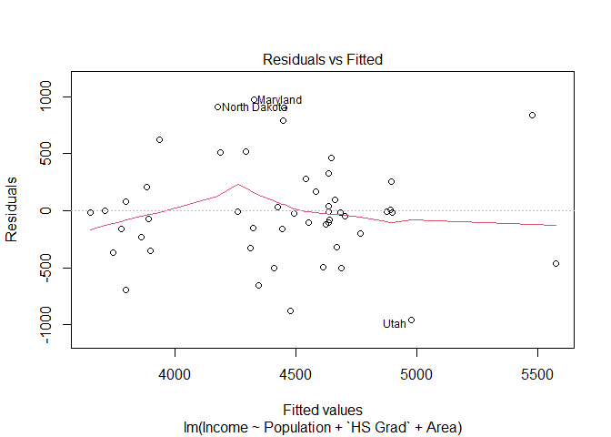

```r
plot(model2,1)
```

1. Sisaan di sekitar 0 → Nilai harapan sisaan sama dengan nol
2. Lebar pita sama untuk setiap nilai dugaan → ragam sisaan homogen
3. Pola plot acak → model pas dan ragam sisaan homogen

### Plot sisaan vs urutan

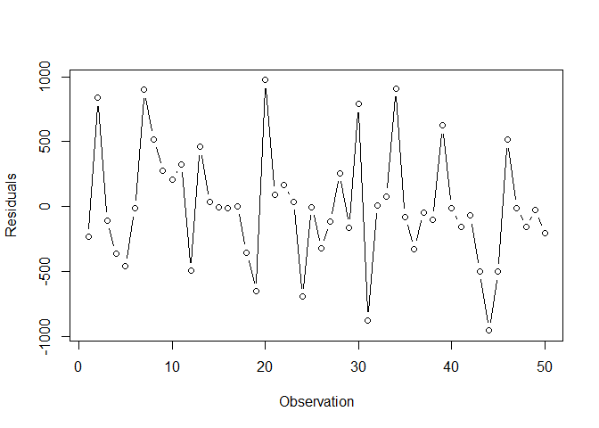

```r
plot(x = 1:dim(data)[1],
     y = model2$residuals,
     type = 'b',
     ylab = "Residuals",
     xlab = "Observation")
```

Tebaran tidak berpola → sisaan saling bebas, model pas

### QQ plot

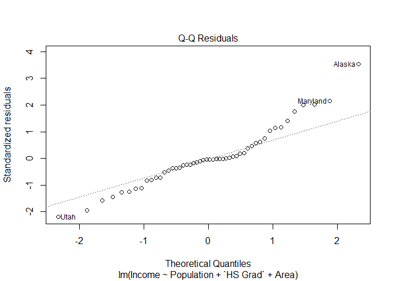

```r
plot(model2,2)
```

## Uji Formal

### Nilai harapan sisaan sama dengan nol

```r
t.test(model2$residuals,mu = 0,conf.level = 0.95)
```

```
##
##  One Sample t-test
##
## data:  model2$residuals
## t = -4.1368e-16, df = 49, p-value = 1
## alternative hypothesis: true mean is not equal to 0
## 95 percent confidence interval:
##  -125.9107  125.9107
## sample estimates:
##     mean of x
## -2.591954e-14
```

Nilai p pada uji t sama dengan 1 yang lebih besar dari alpha 5%, sehingga dinyatakan asumsi nilai harapan sisaan sama dengan nol terpenuhi

### Ragam sisaan homogen

```r
bptest(model2)
```

```
##
##  studentized Breusch-Pagan test
##
## data:  model2
## BP = 3.3253, df = 3, p-value = 0.3441
```

Nilai p pada uji breusch pagan sama dengan 0.3441 yang lebih besar dari alpha 5%, sehingga dinyatakan asumsi ragam sisaan homogen terpenuhi

### Sisaan saling bebas

```r
dwtest(model2)
```

```
##
##  Durbin-Watson test
##
## data:  model2
## DW = 2.0268, p-value = 0.5386
## alternative hypothesis: true autocorrelation is greater than 0
```

Nilai p pada uji durbin watson sama dengan 0.5386 yang lebih besar dari alpha 5%, sehingga dinyatakan asumsi sisaan saling bebas terpenuhi

### Normalitas Sisaan

```r
lillie.test(model2$residuals) # cocok untuk sampel sedang
```

```
##
##  Lilliefors (Kolmogorov-Smirnov) normality test
##
## data:  model2$residuals
## D = 0.14525, p-value = 0.01007
```

```r
shapiro.test(model2$residuals) # cocok untuk sampel kecil
```

```
##
##  Shapiro-Wilk normality test
##
## data:  model2$residuals
## W = 0.9611, p-value = 0.09886
```

# Penanganan Kondisi Tak Standar

## Transformasi Box-Cox

Salah satu langkah penanganan kondisi takstandar berupa normalitas sisaan adalah transformasi peubah respons. Metode transformasi yang sering kali digunakan adalah metode Box-Cox menggunakan fungsi boxcox dengan rumus transformasi sebagai berikut.

$$y' =
\begin{cases}
\frac{y^\lambda - 1}{\lambda}, & \text{jika } \lambda \neq 0 \\
\ln(y), & \text{jika } \lambda = 0
\end{cases}$$

```r
bc_model <- boxcox(Income ~ Population + `HS Grad` + Area, data = data,
         lambda = seq(-2, 2, by = 0.1))
```

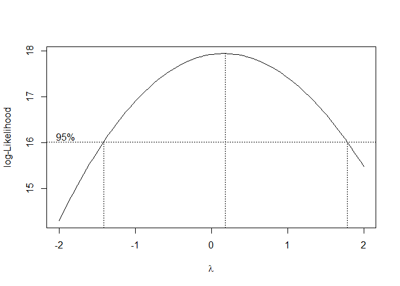

```r
(optimal_lambda <- bc_model$x[which.max(bc_model$y)])
```

```
## [1] 0.1818182
```

Parameter λ optimum dapat diketahui dengan melihat nilai yang memaksimumkan fungsi log-Likelihood di atas. Berdasarkan grafik di atas, diketahui bahwa λ optimum bernilai 0.18182. Selanjutnya proses transformasi peubah respons dilakukan sebagai berikut

```r
data$Income_tr <- ((data$Income)^optimal_lambda)-1/optimal_lambda
```

```r
(data2 <- data[,-1] %>% dplyr::select(Income_tr, everything()))
```

```
##                 Income_tr Population Illiteracy Life Exp Murder HS Grad   Area
## Alabama        -1.0626353       3615        2.1    69.05   15.1    41.3  50708
## Alaska         -0.5911815        365        1.5    69.31   11.3    66.7 566432
## Arizona        -0.8789025       2212        1.8    70.55    7.8    58.1 113417
## Arkansas       -1.1189876       2110        1.9    70.66   10.1    39.9  51945
## California     -0.7758886      21198        1.1    71.71   10.3    62.6 156361
## Colorado       -0.8152493       2541        0.7    72.06    6.8    63.9 103766
## Connecticut    -0.7373027       3100        1.1    72.48    3.1    56.0   4862
## Delaware       -0.8284123        579        0.9    70.06    6.2    54.6   1982
## Florida        -0.8273531       8277        1.3    70.66   10.7    52.6  54090
## Georgia        -0.9637574       4931        2.0    68.54   13.9    40.6  58073
## Hawaii         -0.8015620        868        1.9    73.60    6.2    61.9   6425
## Idaho          -0.9581282        813        0.6    71.87    5.3    59.5  82677
## Illinois       -0.7770649      11197        0.9    70.14   10.3    52.6  55748
## Indiana        -0.8923444       5313        0.7    70.88    7.1    52.9  36097
## Iowa           -0.8608848       2861        0.5    72.56    2.3    59.0  55941
## Kansas         -0.8534393       2280        0.6    72.58    4.5    59.9  81787
## Kentucky       -1.0432361       3387        1.6    70.10   10.6    38.5  39650
## Louisiana      -1.0803816       3806        2.8    68.76   13.2    42.2  44930
## Maine          -1.0471732       1058        0.7    70.39    2.7    54.7  30920
## Maryland       -0.7452666       4122        0.9    70.22    8.5    52.3   9891
## Massachusetts  -0.8379941       5814        1.1    71.83    3.3    58.5   7826
## Michigan       -0.8387074       9111        0.9    70.63   11.1    52.8  56817
## Minnesota      -0.8523542       3921        0.6    72.96    2.3    57.6  79289
## Mississippi    -1.1873712       2341        2.4    68.09   12.5    41.0  47296
## Missouri       -0.9314187       4767        0.8    70.69    9.3    48.8  68995
## Montana        -0.9134194        746        0.6    70.56    5.0    59.2 145587
## Nebraska       -0.8829911       1544        0.6    72.60    2.9    59.3  76483
## Nevada         -0.7700265        590        0.5    69.03   11.5    65.2 109889
## New Hampshire  -0.9261602        812        0.7    71.23    3.3    57.6   9027
## New Jersey     -0.7554303       7333        1.1    70.93    5.2    52.5   7521
## New Mexico     -1.0677690       1144        2.2    70.32    9.7    55.2 121412
## New York       -0.8119410      18076        1.4    70.55   10.9    52.7  47831
## North Carolina -1.0082763       5441        1.8    69.21   11.1    38.5  48798
## North Dakota   -0.7804332        637        0.8    72.78    1.4    50.3  69273
## Ohio           -0.8731689      10735        0.8    70.82    7.4    53.2  40975
## Oklahoma       -0.9857699       2715        1.1    71.42    6.4    51.6  68782
## Oregon         -0.8550691       2284        0.6    72.13    4.2    60.0  96184
## Pennsylvania   -0.8940371      11860        1.0    70.43    6.1    50.2  44966
## Rhode Island   -0.8737223        931        1.3    71.90    2.4    46.4   1049
## South Carolina -1.0601894       2816        2.3    67.96   11.6    37.8  30225
## South Dakota   -0.9485505        681        0.5    72.08    1.7    53.3  75955
## Tennessee      -1.0197225       4173        1.7    70.11   11.0    41.8  41328
## Texas          -0.9443886      12237        2.2    70.90   12.2    47.4 262134
## Utah           -0.9777652       1203        0.6    72.90    4.5    67.3  82096
## Vermont        -1.0015548        472        0.6    71.64    5.5    57.1   9267
## Virginia       -0.8476653       4981        1.4    70.08    9.5    47.8  39780
## Washington     -0.8187432       3559        0.6    71.72    4.3    63.5  66570
## West Virginia  -1.0641949       1799        1.4    69.48    6.7    41.6  24070
## Wisconsin      -0.8904669       4589        0.7    72.48    3.0    54.5  54464
## Wyoming        -0.8722471        376        0.6    70.29    6.9    62.9  97203
```

# Diagnostik Sisaan Hasil Transformasi

Selanjutnya dilakukan pemodelan dan diagnostik sisaan kembali pada data baru dengan peubah respons yang sudah ditransformasi.

```r
model3 <- lm(Income_tr~Population + Illiteracy + `HS Grad` + Area, data = data2)
summary(model3)
```

```
##
## Call:
## lm(formula = Income_tr ~ Population + Illiteracy + `HS Grad` +
##     Area, data = data2)
##
## Residuals:
##      Min       1Q   Median       3Q      Max
## -0.17214 -0.04344 -0.01139  0.03982  0.16858
##
## Coefficients:
##               Estimate Std. Error t value Pr(>|t|)
## (Intercept) -1.252e+00  1.457e-01  -8.597 4.74e-11 ***
## Population   7.421e-06  2.742e-06   2.706  0.00959 **
## Illiteracy  -4.178e-02  2.913e-02  -1.434  0.15837
## `HS Grad`    6.577e-03  2.326e-03   2.827  0.00698 **
## Area         2.476e-07  1.664e-07   1.488  0.14371
## ---
## Signif. codes:  0 '***' 0.001 '**' 0.01 '*' 0.05 '.' 0.1 ' ' 1
##
## Residual standard error: 0.08508 on 45 degrees of freedom
## Multiple R-squared:  0.5115, Adjusted R-squared:  0.4681
## F-statistic: 11.78 on 4 and 45 DF,  p-value: 1.247e-06
```

## Eksplorasi Grafik

### Plot Sisaan vs Yduga

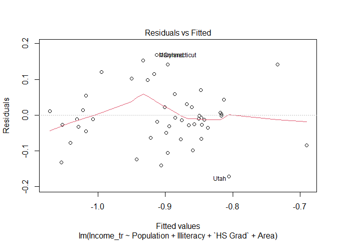

```r
plot(model3,1)
```

1. Sisaan di sekitar 0 → Nilai harapan sisaan sama dengan nol
2. Lebar pita sama untuk setiap nilai dugaan → ragam sisaan homogen
3. Pola plot acak → model pas dan ragam sisaan homogen

### Plot sisaan vs urutan

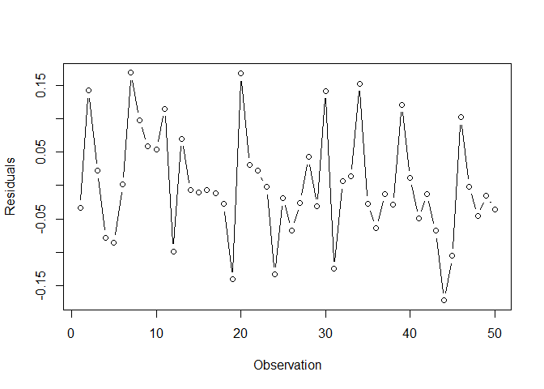

```r
plot(x = 1:dim(data2)[1],
     y = model3$residuals,
     type = 'b',
     ylab = "Residuals",
     xlab = "Observation")
```

Tebaran tidak berpola → sisaan saling bebas, model pas

### QQ plot

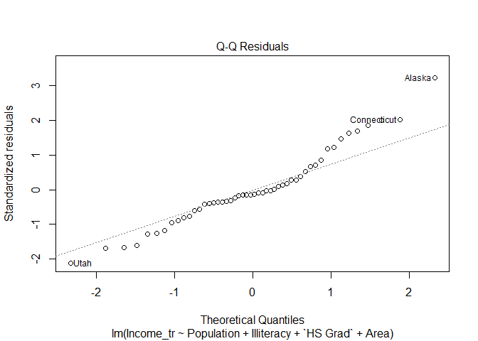

```r
plot(model3,2)
```

Amatan cenderung mengikuti garis pola sehingga sisaan menyebar normal

## Uji Formal

### Nilai harapan sisaan sama dengan nol

```r
t.test(model3$residuals,mu = 0,conf.level = 0.95)
```

```
##
##  One Sample t-test
##
## data:  model3$residuals
## t = -3.4174e-17, df = 49, p-value = 1
## alternative hypothesis: true mean is not equal to 0
## 95 percent confidence interval:
##  -0.02317146  0.02317146
## sample estimates:
##     mean of x
## -3.940397e-19
```

Nilai p pada uji t sama dengan 1 yang lebih besar dari alpha 5%, sehingga dinyatakan asumsi nilai harapan sisaan sama dengan nol terpenuhi

### Ragam sisaan homogen

```r
bptest(model3)
```

```
##
##  studentized Breusch-Pagan test
##
## data:  model3
## BP = 4.8087, df = 4, p-value = 0.3075
```

Nilai p pada uji breusch pagan sama dengan 0.3075 yang lebih besar dari alpha 5%, sehingga dinyatakan asumsi ragam sisaan homogen terpenuhi

### Sisaan saling bebas

```r
dwtest(model3)
```

```
##
##  Durbin-Watson test
##
## data:  model3
## DW = 1.9726, p-value = 0.4624
## alternative hypothesis: true autocorrelation is greater than 0
```

Nilai p pada uji durbin watson sama dengan 0.4624 yang lebih besar dari alpha 5%, sehingga dinyatakan asumsi sisaan saling bebas terpenuhi

### Normalitas Sisaan

```r
lillie.test(model3$residuals) # cocok untuk sampel sedang
```

```
##
##  Lilliefors (Kolmogorov-Smirnov) normality test
##
## data:  model3$residuals
## D = 0.11324, p-value = 0.1124
```

Nilai p pada uji lilliefors menghasilkan nilai p sebesar 0.1124 yang lebih besar dari alpha 5%, sehingga dinyatakan asumsi normalitas sisaan terpenuhi.

# Transformasi Balik